# TNF phosphoproteomics analysis

LUBAC PUB domain interactions restrict Met1-linked ubiquitination to prevent embryonic lethality and immune pathology in mice

Author

Giulia Franciosa

# 1. Setup

Phosphoproteomics analysis of TNF responses in HCT116 cells. See README for methods, installation and data access.

```r
# 1. Load required packages
library(data.table)
library(dplyr)
library(ggplot2)
library(tidyr)
library(stringr)
library(tibble)
library(DAPAR)
library(limma)
library(eulerr)
library(KEGGREST)
library(pheatmap)
library(RColorBrewer)

# 2. Load required functions
source("R/make_long.R")
source("R/prepare_heatmap.R")

# 3. Define input and output paths
input_file <- params$input_file
output_dir <- params$output_dir
plots_dir <- file.path(output_dir, "plots")

# 4. Create output directories
dir.create(output_dir, recursive = TRUE, showWarnings = FALSE)
dir.create(plots_dir, recursive = TRUE, showWarnings = FALSE)
```

# 2. Load data

Load the pivot report, keep human phosphosites and human entries with gene names and phospho-STY measurements.

```r
# 1. Load data
data <- fread(input_file)
data <- as.data.frame(data)
cat("Loaded data with", nrow(data), "rows")
```

```
Loaded data with 75959 rows
```

```r
# 2. Filter data

# Remove contaminants
data <- data[data$PG.FastaFiles == "human_uniprotkb_reviewed_2024_05_24",]
data <- data %>% select(-PG.FastaFiles)

# Remove rows without a Gene name
data <- data[data$PG.Genes != "",]

# Keep Phospho
data <- data[data$PTM.ModificationTitle == "Phospho (STY)",]
data <- data %>% select(-PTM.ModificationTitle)
```

# 3. Shorten sample names

```r
# 1. Remove ".raw.PTM.Quantity"
colnames(data) <- gsub(".raw.PTM.Quantity", "", colnames(data))

# 2. Remove text before "GF"
colnames(data) <- gsub(".*HCT116_", "", colnames(data))
```

# 4. Convert quantities and apply log2

Columns 10–81 contain the 72 measurements. Set values below 1 to NA, then log2-transform.

```r
# 1. Change quantity cols to numerical
data[,10:81] <- sapply(data[,10:81], as.numeric)

# 2. Replace all values < 1 with NA
data[,10:81][data[,10:81] < 1] <- NA

# 3. Log2 transformation
data[,10:81] <- log2(data[,10:81])
```

# 5. Remove duplicates and the outlier run

Remove duplicates and KO_Ctrl_05min_d1_1; the 71 remaining measurements are in columns 10–80.

```r
# 1. Remove duplicates
# Keep rows with unique values in all columns except PG.Genes, PG.ProteinDescriptions, PG.ProteinNames, PTM.ProteinId, PTM.CollapseKey, PTM.FlankingRegion
data <- data %>% distinct_at(vars(-PG.Genes, -PG.ProteinDescriptions, -PG.ProteinNames, -PTM.ProteinId, -PTM.CollapseKey, -PTM.FlankingRegion), .keep_all = TRUE)

# 2. Remove outlier
data <- data %>% select(-KO_Ctrl_05min_d1_1)

cat("Filtered data to", nrow(data), "rows")
```

```
Filtered data to 65565 rows
```

```r
# 3. Export data cleaned
write.table(data, file.path(output_dir, "data_cleaned.txt"), sep = "\t", quote = F, row.names = F)
```

# 6. Filter missing observations

Require more than 50% observed values overall and at least four in one genotype–treatment group.

```r
# 1. Keep rows with more than 50% values present
data_f <- data[rowSums(!is.na(data[,10:80])) > 0.5 * ncol(data[,10:80]),]

col_KO_Ctrl <- grep("KO_Ctrl", colnames(data))
col_KO_TNF <- grep("KO_TNF", colnames(data))
col_WT_Ctrl <- grep("WT_Ctrl", colnames(data))
col_WT_TNF <- grep("WT_TNF", colnames(data))
col_ND_Ctrl <- grep("ND_Ctrl", colnames(data))
col_ND_TNF <- grep("ND_TNF", colnames(data))

# 2. Keep rows with at least 4 values in one condition
data_f <- data_f[rowSums(!is.na(data_f[, col_KO_Ctrl])) >= 4 |
                   rowSums(!is.na(data_f[, col_KO_TNF])) >= 4 |
                   rowSums(!is.na(data_f[, col_WT_Ctrl])) >= 4 |
                   rowSums(!is.na(data_f[, col_WT_TNF])) >= 4 |
                   rowSums(!is.na(data_f[, col_ND_Ctrl])) >= 4 |
                   rowSums(!is.na(data_f[, col_ND_TNF])) >= 4, ]

cat("Filtered data to", nrow(data_f), "rows")
```

```
Filtered data to 15253 rows
```

```r
# 3. Export data filtered
write.table(data_f, file.path(output_dir, "data_filtered.txt"), sep = "\t", quote = F, row.names = F)
```

# 7. Reshape the filtered data

Reshape data_f to long format and recover sample labels for plotting.

```r
long <- make_long(data_f)
```

# 8. Plot filtered distributions

Inspect filtered log2 quantities before normalization.

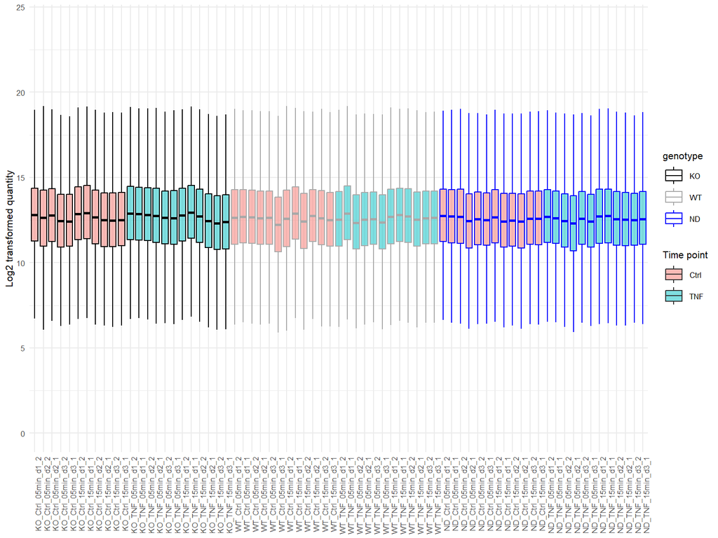

```r
ggplot(long, aes(x = Run, y = quantity, fill = treatment, color = genotype)) +
  geom_boxplot(outlier.shape = NA, position = position_dodge(width = 0.9), alpha = 0.5, lwd = 0.5) +
  scale_color_manual(values = c("black", "darkgrey", "blue")) +
  theme_minimal(base_size = 8) +
  theme(axis.text.x = element_text(angle = 90, hjust = 1)) +
  labs(y = "Log2 transformed quantity", fill = "Time point", x = NULL)
```

```r
# Save plot in pdf in the plots folder
ggsave(
  filename = file.path(plots_dir, "boxplot_filtered.pdf"),
  width = 8,
  height = 6
)
```

# 9. Count detected phosphosites

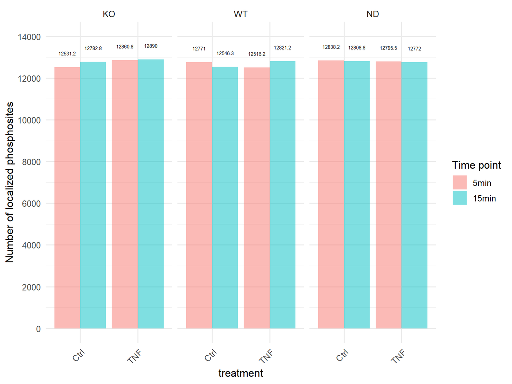

```r
# 1. Count distinct phosphosites per run
totcount <- long %>%
  group_by(Run, genotype, treatment, tp) %>%
  summarise(Count = n_distinct(PTM.CollapseKey), .groups = "drop")

# 2. Mean and SD per genotype, treatment and time point
meancount <- totcount %>%
  group_by(genotype, treatment, tp) %>%
  summarise(
    Count = mean(Count),
    sd = sd(Count),
    .groups = "drop"
  )

# 3. Plot the mean and standard deviation in a bar plot
ggplot(meancount, aes(x = treatment, y = Count, fill = tp)) +
  geom_bar(stat = "identity", position = "dodge", alpha = 0.5) +
  geom_errorbar(aes(ymin = Count - sd, ymax = Count + sd), position = position_dodge(width = 0.9), width = 0.25) +
  geom_text(aes(label = round(Count, 1)), vjust = -3, position = position_dodge(width = 0.9), size=2) +
  theme_minimal(base_size = 12) +
  theme(axis.text.x = element_text(angle = 45, hjust = 1)) +
  labs(y = "Number of localized phosphosites", fill = "Time point") +
  facet_grid(~ genotype) +
  scale_y_continuous(limits = c(0, 14000), breaks = seq(0, 15000, 2000))
```

```r
# Save plot in pdf in the plots folder
ggsave(
  filename = file.path(plots_dir, "barplot_filtered.pdf"),
  width = 8,
  height = 6
)
```

# 10. Normalize after filtering

Median-center log2 quantities with DAPAR; no imputation.

```r
# 1. Normalize data after filtering
norm <- QuantileCentering(
  data_f[,10:80],
  conds = NULL,
  type = "overall",
  quantile = 0.5
)
norm <- as.data.frame(norm)
norm <- cbind(data_f[,1:9], norm)

# 2. Export normalized data
write.table(norm, file.path(output_dir, "data_filtered_norm.txt"), sep = "\t", quote = F, row.names = F)
```

# 11. Reshape the normalized data to long format

```r
long <- make_long(norm)
```

# 12. Plot normalized distributions

Inspect quantities after median centering.

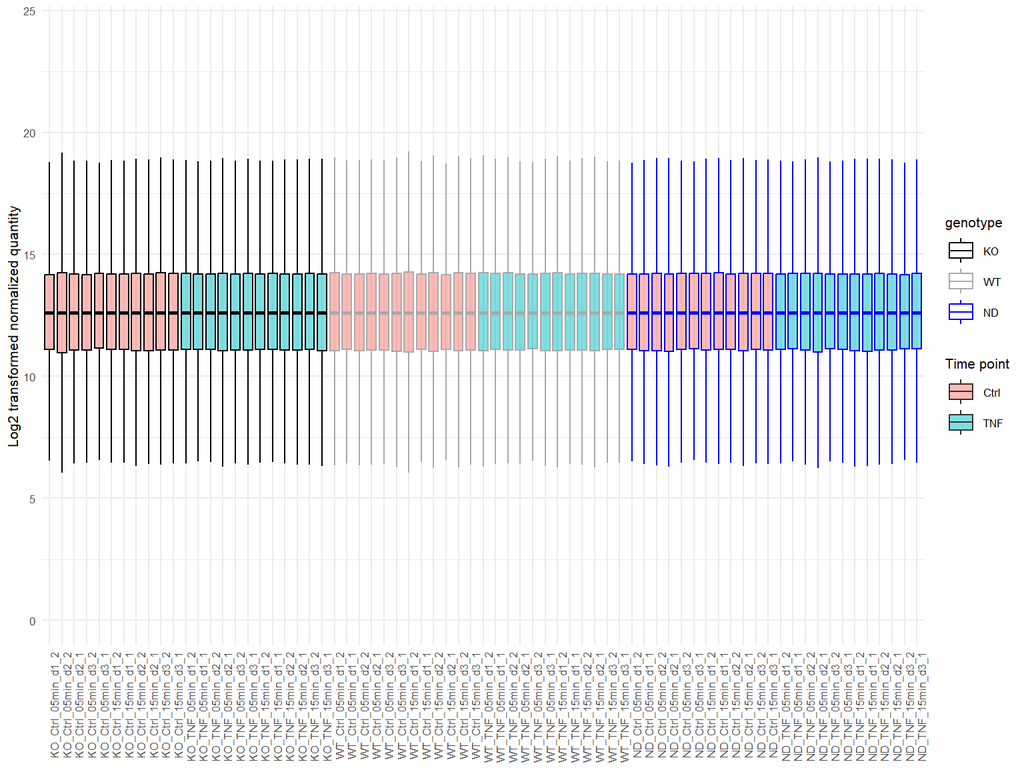

```r
ggplot(long, aes(x = Run, y = quantity, fill = treatment, color = genotype)) +
  geom_boxplot(outlier.shape = NA, position = position_dodge(width = 0.9), alpha = 0.5, lwd = 0.5) +
  scale_color_manual(values = c("black", "darkgrey", "blue")) +
  theme_minimal(base_size = 8) +
  theme(axis.text.x = element_text(angle = 90, hjust = 1)) +
  labs(y = "Log2 transformed normalized quantity", fill = "Time point", x = NULL)
```

```r
# Save plot in pdf in the plots folder
ggsave(
  filename = file.path(plots_dir, "boxplot_filtered_norm.pdf"),
  width = 8,
  height = 6
)
```

# 13. Fit limma and specify contrasts

Fit the group means and 14 contrasts, without replicate blocking.

```r
# 1. Remove the last 5 characters from column names
group <- substr(colnames(norm[,10:80]), 1, nchar(colnames(norm[,10:80]))-5)
unique(group)
```

```
 [1] "ND_TNF_15min"  "ND_Ctrl_15min" "ND_TNF_05min"  "ND_Ctrl_05min"
 [5] "WT_TNF_15min"  "WT_Ctrl_15min" "WT_TNF_05min"  "WT_Ctrl_05min"
 [9] "KO_TNF_15min"  "KO_Ctrl_15min" "KO_TNF_05min"  "KO_Ctrl_05min"
```

```r
# 2. Design matrix
design <- model.matrix(~0 + group)
colnames(design) <- gsub("group", "", colnames(design))

# 3. Fit limma
fit <- lmFit(norm[,10:80], design)

# 4. Specify contrasts
cont.matrix <- makeContrasts(
  WT_5min = WT_TNF_05min - WT_Ctrl_05min,
  WT_15min = WT_TNF_15min - WT_Ctrl_15min,
  KO_5min = KO_TNF_05min - KO_Ctrl_05min,
  KO_15min = KO_TNF_15min - KO_Ctrl_15min,
  ND_5min = ND_TNF_05min - ND_Ctrl_05min,
  ND_15min = ND_TNF_15min - ND_Ctrl_15min,
  KO_WT_5min = KO_Ctrl_05min - WT_Ctrl_05min,
  KO_WT_15min = KO_Ctrl_15min - WT_Ctrl_15min,
  ND_WT_5min = ND_Ctrl_05min - WT_Ctrl_05min,
  ND_WT_15min = ND_Ctrl_15min - WT_Ctrl_15min,
  KO_WT_TNF_5min = KO_TNF_05min - WT_TNF_05min,
  KO_WT_TNF_15min = KO_TNF_15min - WT_TNF_15min,
  ND_WT_TNF_5min = ND_TNF_05min - WT_TNF_05min,
  ND_WT_TNF_15min = ND_TNF_15min - WT_TNF_15min,
  levels = design
)

# 5. Fit contrasts and compute moderated t-statistics
fit2 <- contrasts.fit(fit, cont.matrix)
fit3 <- eBayes(fit2, trend = T)
```

# 14. Collect results and label regulation

Collect limma results and classify regulation using adjusted p-values and fold-change thresholds; see README.

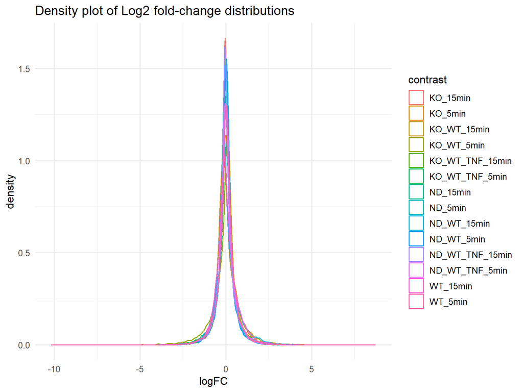

```r
# 1. List of contrasts
coefficients <- c(
  "WT_5min",
  "WT_15min",
  "KO_5min",
  "KO_15min",
  "ND_5min",
  "ND_15min",
  "KO_WT_5min",
  "KO_WT_15min",
  "ND_WT_5min",
  "ND_WT_15min",
  "KO_WT_TNF_5min",
  "KO_WT_TNF_15min",
  "ND_WT_TNF_5min",
  "ND_WT_TNF_15min"
)

# 2. Initialize an empty list to store the results for each contrast
tabs <- list()

# 3. Loop through each contrast, extract the top table, and classify regulation
for (i in coefficients) {
  tab <- topTable(fit3, coef = i, number = Inf, sort.by = "none")
  tab$contrast <- i
  tab <- cbind(norm[,1:9], tab)
  tab <- tab %>%
    mutate(
      Regulation = case_when(
        logFC > 2*sd(tab$logFC[tab$logFC > 0], na.rm = T) & adj.P.Val <= 0.01 ~ "Up-regulated",
        logFC < -(2*sd(tab$logFC[tab$logFC > 0], na.rm = T)) & adj.P.Val <= 0.01 ~ "Down-regulated",
        TRUE ~ "Unchanged"
      )
    )
  tabs[[i]] <- tab
}

# 4. Combine all results into a single data frame
limma <- do.call(rbind, tabs)

# 5. Export limma results
write.table(limma, file.path(output_dir, "limma.txt"), sep = "\t", quote = F, row.names = F)

# 6. Density plot of Log2 fc distributions
ggplot(limma, aes(x = logFC, color = contrast)) +
  geom_density(alpha = 0.5) +
  theme_minimal(base_size = 12) +
  ggtitle("Density plot of Log2 fold-change distributions")
```

# 15. Count regulated sites

Count regulated phosphosites using both the stringent cutoff defined in Step 14 and BH-adjusted p ≤ 0.05.

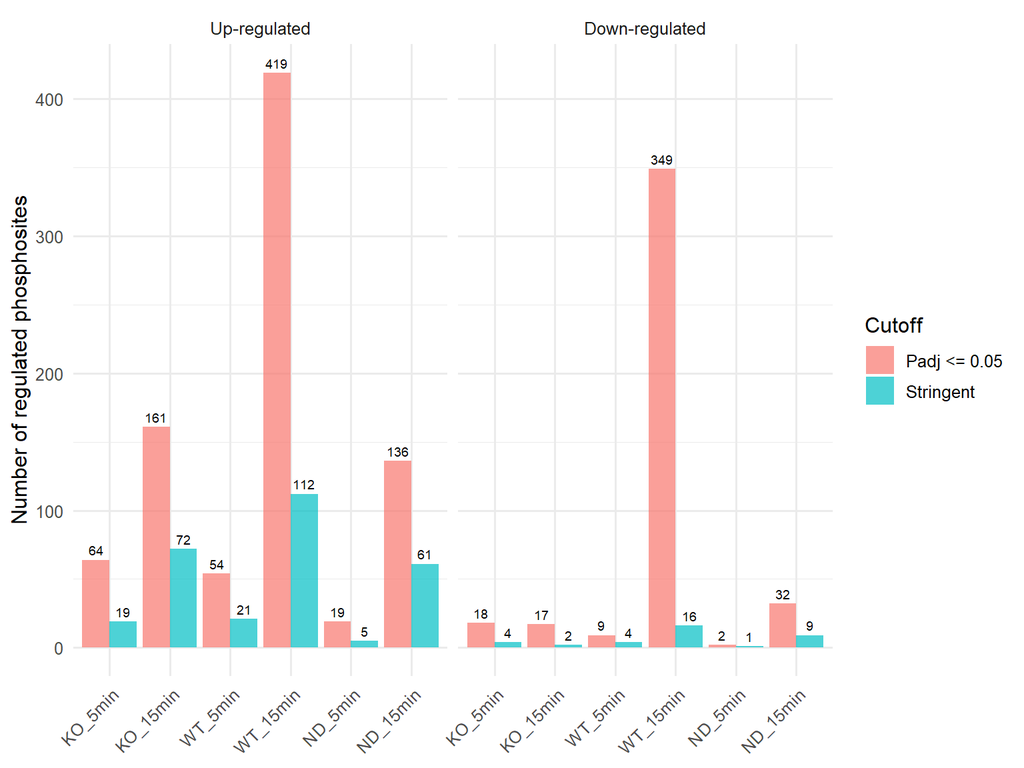

```r
# 1. Count regulated sites using the stringent cutoff defined in Step 14
count_stringent <- limma %>%
  group_by(contrast, Regulation) %>%
  summarise(
    Count = n_distinct(PTM.CollapseKey),
    .groups = "drop"
  ) %>%
  mutate(Cutoff = "Stringent")

# 2. Count regulated sites using adjusted p-value <= 0.05
count_padj <- limma %>%
  mutate(
    Regulation = case_when(
      adj.P.Val <= 0.05 & logFC > 0 ~ "Up-regulated",
      adj.P.Val <= 0.05 & logFC < 0 ~ "Down-regulated",
      TRUE ~ "Unchanged"
    )
  ) %>%
  group_by(contrast, Regulation) %>%
  summarise(
    Count = n_distinct(PTM.CollapseKey),
    .groups = "drop"
  ) %>%
  mutate(Cutoff = "Padj <= 0.05")

# 3. Combine counts
count <- bind_rows(
  count_stringent,
  count_padj
) %>%
  mutate(
    Regulation = factor(
      Regulation,
      levels = c("Up-regulated", "Down-regulated", "Unchanged")
    ),
    Cutoff = factor(
      Cutoff,
      levels = c("Padj <= 0.05", "Stringent")
    )
  )


# 4. TNF response contrasts
tnf_contrasts <- c(
  "KO_5min", "KO_15min",
  "WT_5min", "WT_15min",
  "ND_5min", "ND_15min"
)

count_tnf <- count %>%
  filter(contrast %in% tnf_contrasts) %>%
  mutate(
    contrast = factor(contrast, levels = tnf_contrasts)
  )

ggplot(
  count_tnf %>% filter(Regulation != "Unchanged"),
  aes(
    x = contrast,
    y = Count,
    fill = Cutoff
  )
) +
  geom_col(
    position = position_dodge(width = 0.9),
    alpha = 0.7
  ) +
  geom_text(
    aes(label = Count),
    position = position_dodge(width = 0.9),
    vjust = -0.5,
    size = 2.5
  ) +
  theme_minimal(base_size = 12) +
  theme(
    axis.text.x = element_text(angle = 45, hjust = 1)
  ) +
  labs(
    x = NULL,
    y = "Number of regulated phosphosites",
    fill = "Cutoff"
  ) +
  facet_wrap(~ Regulation)
```

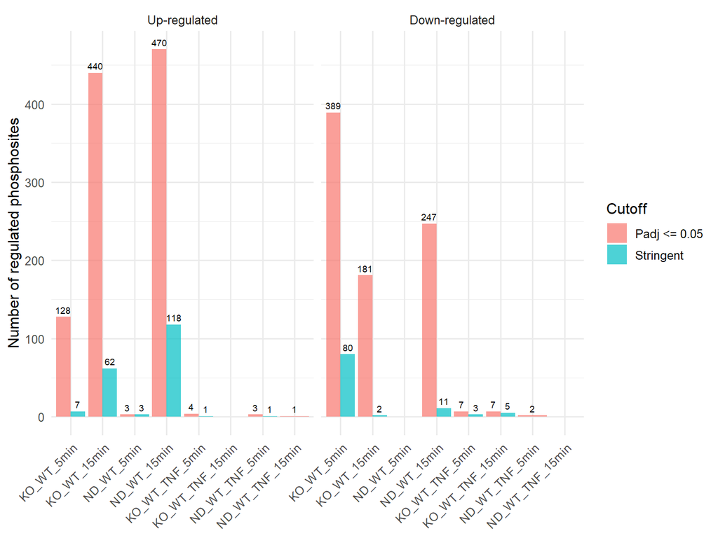

```r
# Save plot in pdf in the plots folder
ggsave(
  filename = file.path(plots_dir, "bar_plot_tnf.pdf"),
  width = 8,
  height = 6
)

# 5. Genotype comparison contrasts
genotype_contrasts <- c(
  "KO_WT_5min", "KO_WT_15min",
  "ND_WT_5min", "ND_WT_15min",
  "KO_WT_TNF_5min", "KO_WT_TNF_15min",
  "ND_WT_TNF_5min", "ND_WT_TNF_15min"
)

count_genotype <- count %>%
  filter(contrast %in% genotype_contrasts) %>%
  mutate(
    contrast = factor(
      contrast,
      levels = genotype_contrasts
    )
  )

ggplot(
  count_genotype %>% filter(Regulation != "Unchanged"),
  aes(
    x = contrast,
    y = Count,
    fill = Cutoff
  )
) +
  geom_col(
    position = position_dodge(width = 0.9),
    alpha = 0.7
  ) +
  geom_text(
    aes(label = Count),
    position = position_dodge(width = 0.9),
    vjust = -0.5,
    size = 2.5
  ) +
  theme_minimal(base_size = 12) +
  theme(
    axis.text.x = element_text(angle = 45, hjust = 1)
  ) +
  labs(
    x = NULL,
    y = "Number of regulated phosphosites",
    fill = "Cutoff"
  ) +
  facet_wrap(~ Regulation)
```

```r
# Save plot in pdf in the plots folder
ggsave(
  filename = file.path(plots_dir, "bar_plot_genotype.pdf"),
  width = 8,
  height = 6
)
```

# 16. Plot overlap between genotypes

Use stringent Regulation labels for the genotype-overlap plots.

```r
# 1. Helper function to get regulated sites for a given contrast
get_regulated_sites <- function(limma_results, contrast_name) {

  limma_results %>%
    filter(
      contrast == contrast_name,
      Regulation != "Unchanged"
    ) %>%
    distinct(PTM.CollapseKey) %>%
    pull(PTM.CollapseKey)
}

# 2. Plot overlap of regulated phosphosites at 5 minutes
overlap_5min <- list(
  WT = get_regulated_sites(limma, "WT_5min"),
  KO = get_regulated_sites(limma, "KO_5min"),
  ND = get_regulated_sites(limma, "ND_5min")
)

# Create plot object
euler_5min <- plot(
  euler(overlap_5min),
  quantities = TRUE,
  fills = c("lightblue", "lightpink", "lightgreen"),
  main = "Regulated phosphosites - 5 min"
)

# Save as PDF
pdf(
  file.path(plots_dir, "regulated_phosphosites_overlap_5min.pdf"),
  width = 7,
  height = 7
)

print(euler_5min)
dev.off()
```

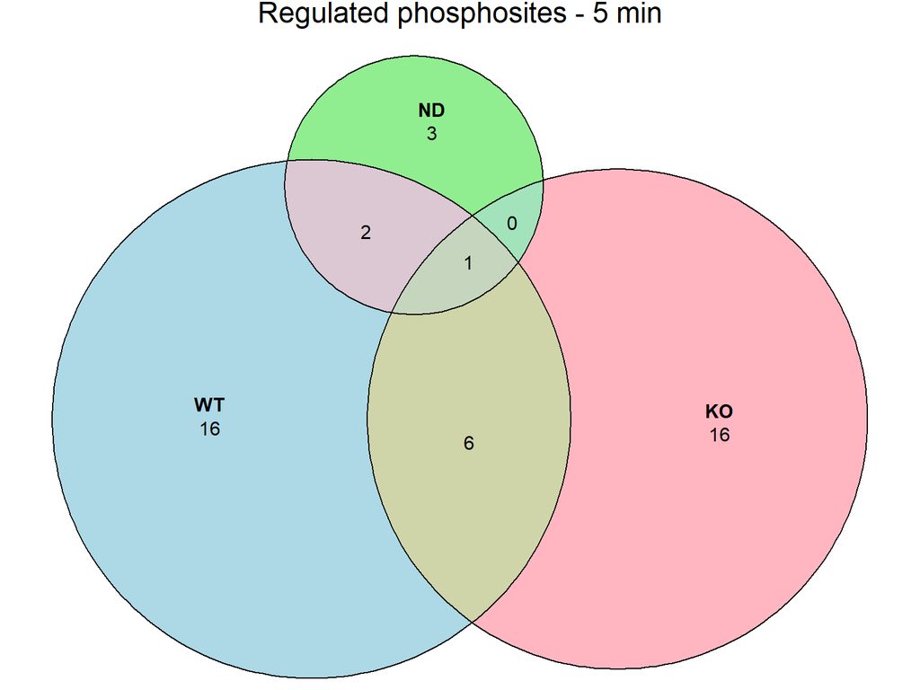

```r
# Display in QMD
print(euler_5min)
```

```r
# 3. Plot overlap of regulated phosphosites at 15 minutes
overlap_15min <- list(
  WT = get_regulated_sites(limma, "WT_15min"),
  KO = get_regulated_sites(limma, "KO_15min"),
  ND = get_regulated_sites(limma, "ND_15min")
)

euler_15min <- plot(
  euler(overlap_15min),
  quantities = TRUE,
  fills = c("lightblue", "lightpink", "lightgreen"),
  main = "Regulated phosphosites - 15 min"
)

pdf(
  file.path(plots_dir, "regulated_phosphosites_overlap_15min.pdf"),
  width = 7,
  height = 7
)

print(euler_15min)
dev.off()
```

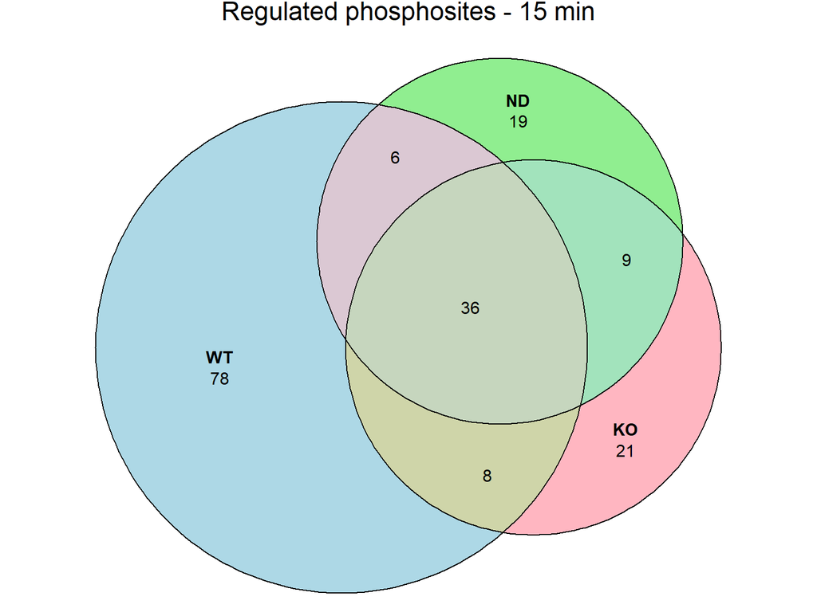

```r
print(euler_15min)
```

# 17. Heatmaps

## 17.1 TNF-responsive phosphosites at 15 minutes

```r
# 1. Select TNF-responsive phosphosites
sites_15min_padj_fc <- limma %>%
  filter(
    contrast %in% c("WT_15min", "KO_15min", "ND_15min"),
    Regulation != "Unchanged"
  ) %>%
  distinct(PTM.CollapseKey) %>%
  pull(PTM.CollapseKey)

cat("Number of TNF-responsive phosphosites at 15 minutes:", length(sites_15min_padj_fc), "\n")
```

```
Number of TNF-responsive phosphosites at 15 minutes: 177
```

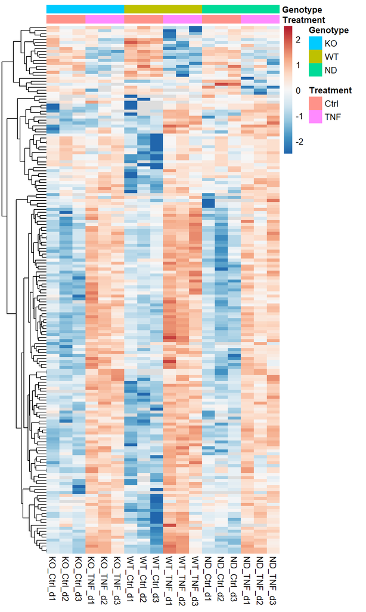

```r
# 2. Prepare heatmap
heatmap_15min_padj_fc <- prepare_heatmap(
  long,
  sites_15min_padj_fc,
  "15min"
)

# 3. Plot the heatmap
hm <- pheatmap(
  heatmap_15min_padj_fc$matrix,
  color = colorRampPalette(
    rev(brewer.pal(n = 9, name = "RdBu"))
  )(100),
  breaks = seq(-2.5, 2.5, length.out = 101),
  annotation_col = heatmap_15min_padj_fc$annotation,
  show_rownames = FALSE,
  cluster_cols = FALSE
)
```

```r
# 4. Save heatmap
pdf(
  file.path(plots_dir, "heatmap_15min_padj_fc.pdf"),
  width = 8,
  height = 10
)

grid::grid.draw(hm$gtable)
dev.off()
```

## 17.2 Genotype-dependent TNF-responsive phosphosites at 15 minutes

```r
# 1. Phosphosites different between WT and KO or N102D under TNF
genotype_sites_15min <- limma %>%
  filter(
    contrast %in% c(
      "KO_WT_TNF_15min",
      "ND_WT_TNF_15min"
    ),
    P.Value < 0.05
  ) %>%
  distinct(PTM.CollapseKey) %>%
  pull(PTM.CollapseKey)

cat("Number of genotype-dependent phosphosites at 15 minutes:", length(genotype_sites_15min), "\n")
```

```
Number of genotype-dependent phosphosites at 15 minutes: 1503
```

```r
# 2. Require both criteria
sites_15min_padj_fc_pval <- intersect(
  sites_15min_padj_fc,
  genotype_sites_15min
)

cat("Number of genotype-dependent TNF-responsive phosphosites at 15 minutes:", length(sites_15min_padj_fc_pval), "\n")
```

```
Number of genotype-dependent TNF-responsive phosphosites at 15 minutes: 48
```

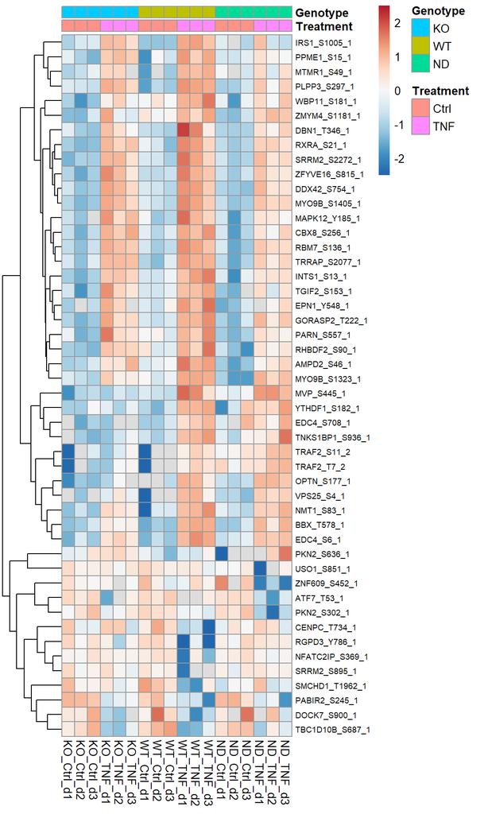

```r
# 3. Prepare heatmap
heatmap_15min_padj_fc_pval <- prepare_heatmap(
  long,
  sites_15min_padj_fc_pval,
  "15min"
)

# 4. Plot the heatmap
hm2 <- pheatmap(
  heatmap_15min_padj_fc_pval$matrix,
  color = colorRampPalette(
    rev(brewer.pal(n = 9, name = "RdBu"))
  )(100),
  breaks = seq(-2.5, 2.5, length.out = 101),
  annotation_col = heatmap_15min_padj_fc_pval$annotation,
  show_rownames = TRUE,
  fontsize_row = 7,
  cluster_cols = FALSE
)
```

```r
# 5. Save heatmap
pdf(
  file.path(plots_dir, "heatmap_15min_padj_fc_pval.pdf"),
  width = 8,
  height = 10
)

grid::grid.draw(hm2$gtable)
dev.off()
```

## 17.3 KEGG TNF and NF-κB pathway heatmap

```r
# 1. Retrieve genes from TNF and NF-kB KEGG pathways
pathway_tnf <- keggGet("hsa04668")
pathway_nfkb <- keggGet("hsa04064")

genes_tnf <- pathway_tnf[[1]]$GENE
genes_nfkb <- pathway_nfkb[[1]]$GENE

gene_names_tnf <- genes_tnf[
  seq(2, length(genes_tnf), by = 2)
] %>%
  sapply(function(x) strsplit(x, ";")[[1]][1])

gene_names_nfkb <- genes_nfkb[
  seq(2, length(genes_nfkb), by = 2)
] %>%
  sapply(function(x) strsplit(x, ";")[[1]][1])

kegg_genes <- unique(
  c(gene_names_tnf, gene_names_nfkb)
)
cat("Number of unique genes in KEGG TNF and NF-kB pathways:", length(kegg_genes), "\n")
```

```
Number of unique genes in KEGG TNF and NF-kB pathways: 191
```

```r
# 2. Select regulated phosphosites
kegg_sites <- limma %>%
  filter(adj.P.Val <= 0.05) %>%
  distinct(PTM.CollapseKey) %>%
  pull(PTM.CollapseKey)

# 3. Prepare KEGG phosphosites for heatmap
kegg_heatmap_data <- long %>%
  mutate(
    Gene = gsub(";.*", "", PG.Genes)
  ) %>%
  filter(
    Gene %in% kegg_genes,
    PTM.CollapseKey %in% kegg_sites
  ) %>%
  mutate(
    id = paste0(
      Gene, "_",
      PTM.SiteAA, PTM.SiteLocation, "_",
      PTM.Multiplicity
    )
  ) %>%
  group_by(PTM.CollapseKey, id) %>%
  mutate(
    z = as.numeric(scale(quantity))
  ) %>%
  ungroup() %>%
  group_by(
    PTM.CollapseKey,
    id,
    genotype,
    treatment,
    tp,
    rep
  ) %>%
  summarise(
    z = mean(z, na.rm = TRUE),
    .groups = "drop"
  ) %>%
  mutate(
    condition = paste0(
      genotype, "_",
      treatment, "_",
      tp, "_",
      rep
    )
  )

# 4. Convert to wide format
kegg_wide <- data.table::dcast(
  as.data.table(kegg_heatmap_data),
  id ~ condition,
  value.var = "z"
)
cat("Number of KEGG phosphosites for heatmap:", nrow(kegg_wide), "\n")
```

```
Number of KEGG phosphosites for heatmap: 38
```

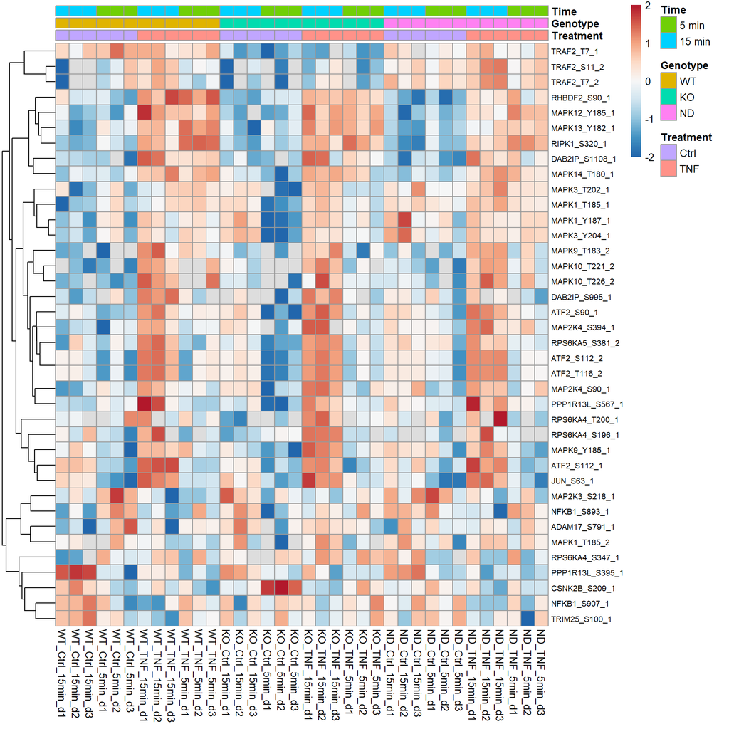

```r
kegg_wide <- as.data.frame(kegg_wide)

rownames(kegg_wide) <- kegg_wide$id
kegg_wide$id <- NULL

# 5. Order columns
column_order <- c(
  grep("^WT_", colnames(kegg_wide), value = TRUE),
  grep("^KO_", colnames(kegg_wide), value = TRUE),
  grep("^ND_", colnames(kegg_wide), value = TRUE)
)

kegg_wide <- kegg_wide[
  ,
  column_order,
  drop = FALSE
]

# 6. Column annotations
kegg_annotation <- data.frame(
  Treatment = ifelse(
    grepl("_TNF_", colnames(kegg_wide)),
    "TNF",
    "Ctrl"
  ),
  Genotype = case_when(
    grepl("^WT_", colnames(kegg_wide)) ~ "WT",
    grepl("^KO_", colnames(kegg_wide)) ~ "KO",
    grepl("^ND_", colnames(kegg_wide)) ~ "ND"
  ),
  Time = case_when(
    grepl("_5min_", colnames(kegg_wide)) ~ "5 min",
    grepl("_15min_", colnames(kegg_wide)) ~ "15 min"
  ),
  row.names = colnames(kegg_wide)
)

kegg_annotation$Treatment <- factor(
  kegg_annotation$Treatment,
  levels = c("Ctrl", "TNF")
)

kegg_annotation$Genotype <- factor(
  kegg_annotation$Genotype,
  levels = c("WT", "KO", "ND")
)

kegg_annotation$Time <- factor(
  kegg_annotation$Time,
  levels = c("5 min", "15 min")
)

# 7. Plot heatmap
kegg_plot <- pheatmap(
  as.matrix(kegg_wide),
  color = colorRampPalette(
    rev(brewer.pal(n = 9, name = "RdBu"))
  )(100),
  breaks = seq(-2, 2, length.out = 101),
  annotation_col = kegg_annotation,
  show_rownames = TRUE,
  fontsize_row = 8,
  cluster_cols = FALSE
)
```

```r
# 8. Save heatmap
pdf(
  file.path(plots_dir, "heatmap_TNF_NFkb_bio-rep.pdf"),
  width = 8,
  height = 10
)

grid::grid.draw(kegg_plot$gtable)
dev.off()
```

# 18. Session information

```r
writeLines(
  file.path(output_dir, "sessionInfo.txt")
)
```

[output not shown]